# Joinplot - Pariplot

```python
import seaborn as sns
import matplotlib.pyplot as plt
```

```python
tips = sns.load_dataset('tips')
tips.head(3)
```

|  | total_bill | tip | sex | smoker | day | time | size |
| --- | --- | --- | --- | --- | --- | --- | --- |
| 0 | 16.99 | 1.01 | Female | No | Sun | Dinner | 2 |
| 1 | 10.34 | 1.66 | Male | No | Sun | Dinner | 3 |
| 2 | 21.01 | 3.50 | Male | No | Sun | Dinner | 3 |

## Joinplot

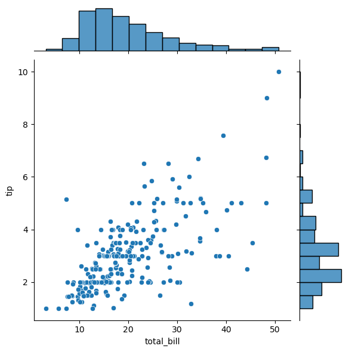

```python
#Joinplot
sns.jointplot(data=tips,x='total_bill',y='tip')
plt.show()
```

Cómo se puede observar, junta un gráfico `scatter` y un `histograma`, que relaciona 2 variables. Nos ayuda a visualizar que hay 2 histogramas una en el eje `x` y otro en el eje `y`.

### Personalizando

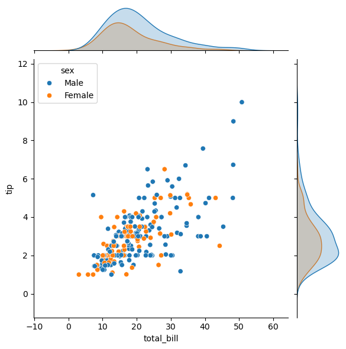

```python
#Join
#hue='sex'
sns.jointplot(data=tips,x='total_bill',y='tip',hue='sex')
plt.show()
```

Aquí automaticamente, cambia dependiendo del diagrama más adecuado. 2 de tipo `KDE` y uno `scatter`.

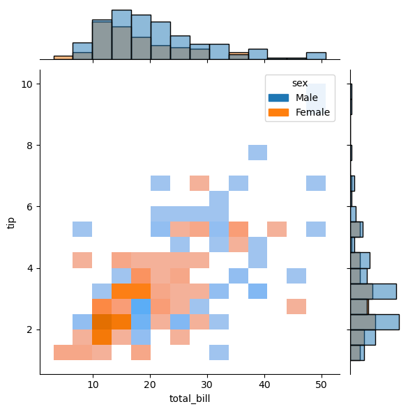

```python
#Especificando que hue='sex' se muestre como hist
#kind='hist'
sns.jointplot(data=tips,x='total_bill',y='tip',hue='sex',kind='hist')
plt.show()
```

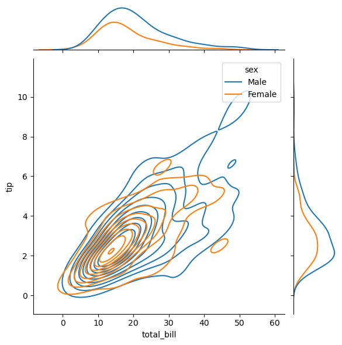

```python
#Especificando que hue='sex' se muestre como kde
#kind='kde'
sns.jointplot(data=tips,x='total_bill',y='tip',hue='sex',kind='kde')
plt.show()
```

### Marginal ticks=True

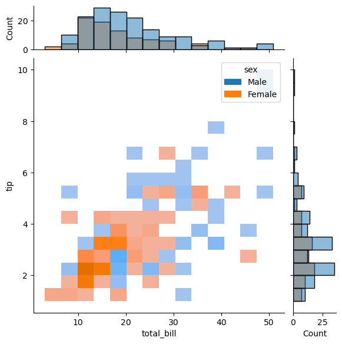

```python
#Especificando que hue='sex' se muestre como hist
#kind='hist'
#Mas valor en los ejes
sns.jointplot(data=tips,x='total_bill',y='tip',hue='sex',kind='hist',marginal_ticks=True)
plt.show()
```

### Marginal_kws

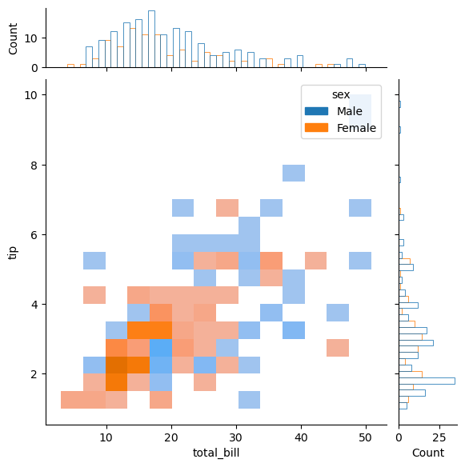

```python
#Especificando que hue='sex' se muestre como hist
#kind='hist'
#Mas valor en los ejes
sns.jointplot(data=tips,x='total_bill',y='tip',hue='sex',kind='hist',marginal_ticks=True,
              marginal_kws=dict(bins=25,fill=False,multiple='dodge'))
plt.show()
```

## Pairplot

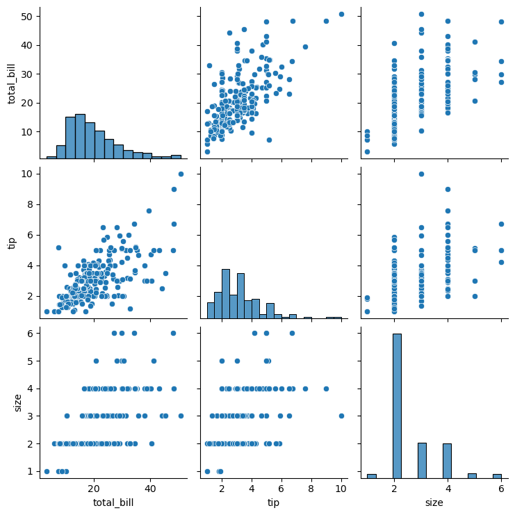

```python
#Pairplot
sns.pairplot(data=tips)
plt.show()
```

### Explicación:

Este método toma `total_bill`, `tip` y `size`. Las 3 son variables numericas y sirven muy bien para la relación entre si, entonces `pairplot()` de manera automatica las relaciona entre si. Notas:

- Siempre la relación de la variable con si misma, nos dará un histograma.
- En otra forma puede hacer scatter plot

### Personalizando

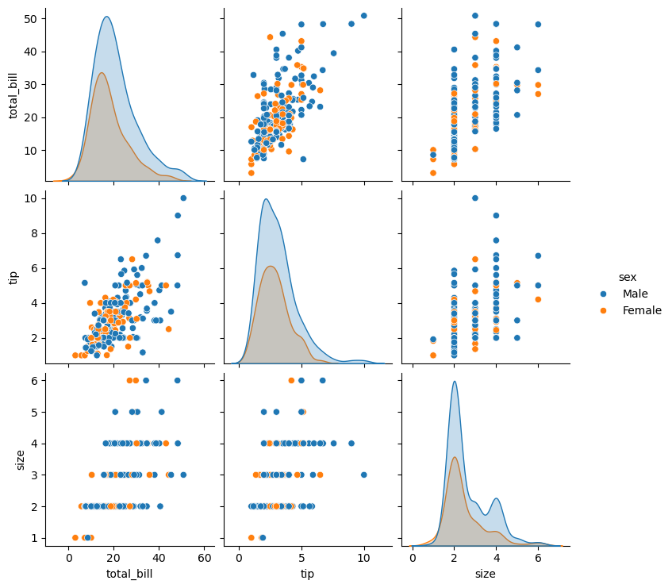

```python
#Pairplot
sns.pairplot(data=tips,hue='sex')
plt.show()
```

Ahora considera que es mejor representar con un diagrama de `KDE` la relación de variable consigo mismo.

### palette= Y corner=True

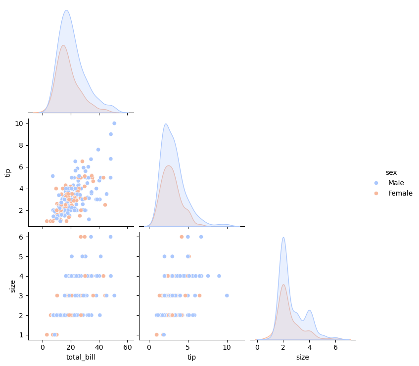

```python
#Pairplot
sns.pairplot(data=tips,hue='sex',palette='coolwarm',corner=True)
plt.show()
```

### Explicación de Corner:

Corner me sirve para no tener información duplicada, es decir como se relacionan por pares, puede que existan relaciones duplicadas y pueden parecer gráficas diferentes, pero en realidad no lo son.

### Kind='line'

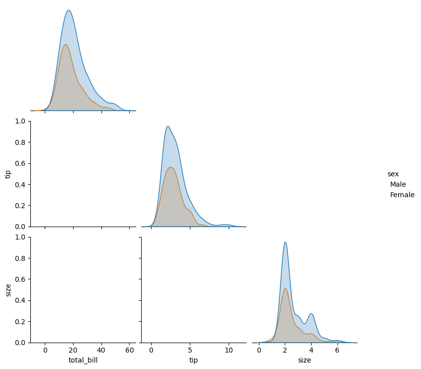

```python
#Pairplot
sns.pairplot(data=tips,hue='sex',corner=True,kind='line')
plt.show()
```

### Kind='scatter'

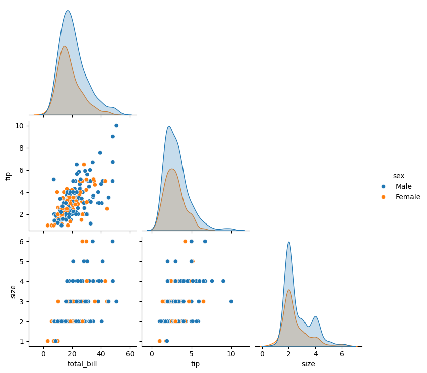

```python
#Pairplot
sns.pairplot(data=tips,hue='sex',corner=True,kind='scatter')
plt.show()
```

Esta es una herramienta muy útil a nivel de analizar tus datos a primera vista

# Referencias:

- [Implot](https://seaborn.pydata.org/generated/seaborn.lmplot.html#seaborn.lmplot)
- [Pairplot](https://seaborn.pydata.org/generated/seaborn.pairplot.html)
- [Joinplot](https://seaborn.pydata.org/generated/seaborn.jointplot.html)